# Blog

2025-09-09

# ~~~~~~~~~~~~~

# 1.January: Gispolygon

This post is to give you an example on how to create your own polygon using google maps.

## Program

For this exercise we used the release candidate of QGIS, but every version has the option to create new layers, so no worries in which version you are using.

[figure not shown]

If you still dont have it, here is the link for download [QGIS](https://www.qgis.org/en/site/forusers/download.html)

## QGIS

In earlier QGIS versions, there was a plugin called **Open Layers plugin**, but is not available anymore (as far as I am aware of).

Now to add a **google satellite** map in your QGIS you could do the following:

1. Go to View > Panels > Activate Browser Panel

[figure not shown]

2. Now go to XYZ > a new connection

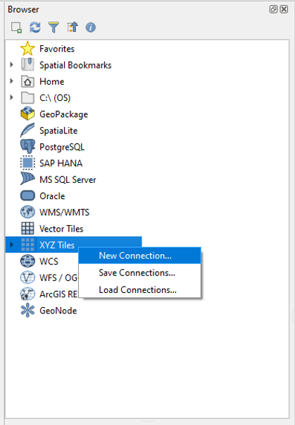

3. A new window will appear

[figure not shown]

4. Fill in the spaces with the map you want to use

You need to give it a name and the **URL**

There are many options of maps, you can look at some here: [Google URLs](https://hatarilabs.com/ih-en/how-to-add-a-google-map-in-qgis-3-tutorial)

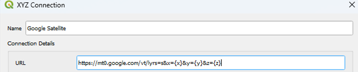

Once you have create the connection, double click on the name and the map should be loaded as a layer.

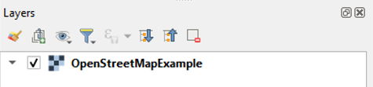

Ready to Use!

[figure not shown]

## Create polygon

1. Select New Shapefile Layer

[figure not shown]

2. Give a name to your new shapefile

I recommend to click on the three dots to select also the directory

In the exercise, we will create a polygon, therefore, select **Polygon** in Geometry type

[figure not shown]

3. Select Layer > Toggle editing, or just click on the icon with the yellow pencil

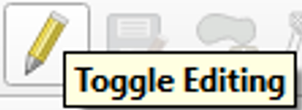

4. Now add polygon feature by clicking on the green polygon icon

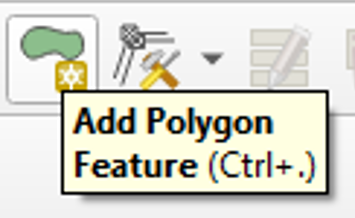

5. Use the pointer of your mouse and click one time to create points

The areas will start to look red

Keep clicking until you have a more or less the polygon you want

When you finish you should add an id, here I used the number 1 for an example

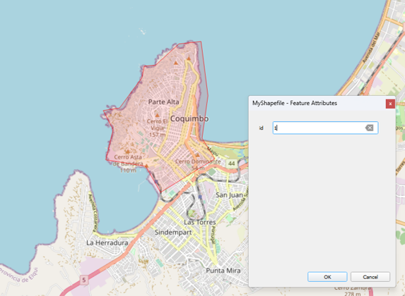

Now you should have a polygon!

7. To edit the shapes you can use the vertex tool

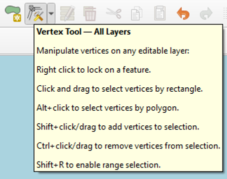

8. The corners can be moved/dragged when the icon has been selected

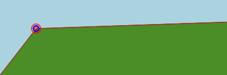

9. New points can be created using the cross

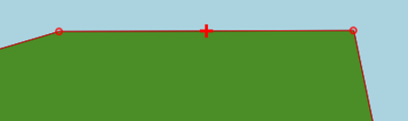

10. When you are editing your layer you will have a red pencil icon, click on the yellow pencil for **finish editing**

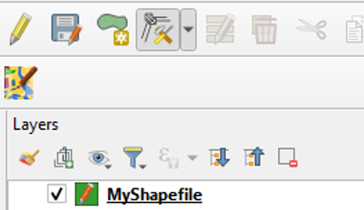

11. Do not forget to save the changes!

[figure not shown]

… Now you are done!

I hope this helped you.

## References

For continuing learning, here are other uses of google maps:

- [Medium](https://medium.com/@nerimbarakat/google-maps-basic-d5ecf00ef922)
- [Add background map](https://www.littlemissdata.com/blog/maps)
- [Google API](https://medium.com/@nerimbarakat/google-maps-basic-d5ecf00ef922)
- [Google URLs](https://hatarilabs.com/ih-en/how-to-add-a-google-map-in-qgis-3-tutorial)

# ~~~~~~~~~~~~~

# 2.February: subset shapefile

# Intro

Three steps to subset a shapefile and export a new shapefile with the attributes you are interested in.

# 1. Load shapefile

Load the package **sf** to load your shapefile into R

```r
library(sf)
```

Load the package **here** to use your directory (in which folder is your shapefile)

```r
library(here)
```

Load your shapefile, be careful with your directory

```r
Old_shapefile<- read_sf(paste0(My_directory,'/Blog/2023/original_shapefile.shp'))
```

Check the class, theoretically it would show sf

```r
class(Old_shapefile)
```

```
## [1] "sf"         "tbl_df"     "tbl"        "data.frame"
```

Explore the contents

```r
str(Old_shapefile)
```

```
## sf [654 × 7] (S3: sf/tbl_df/tbl/data.frame)
##  $ objectid  : num [1:654] 16 17 147 269 270 276 76 18 21 22 ...
##  $ comuna    : chr [1:654] "Copiapó" "Chañaral" "Cunco" "Peralillo" ...
##  $ st_area_sh: num [1:654] 26786663 3337566 628781 1498707 666708 ...
##  $ st_length_: num [1:654] 76929 12855 5378 6527 5770 ...
##  $ Localidad : chr [1:654] "Copiapó" "Chañaral" "Hortensias" "Peralillo" ...
##  $ Entidad   : chr [1:654] "Ciudad" "Ciudad" "Aldea" "Pueblo" ...
##  $ geometry  :sfc_MULTIPOLYGON of length 654; first list element: List of 1
##   ..$ :List of 1
##   .. ..$ : num [1:2535, 1:2] -7832195 -7831985 -7831788 -7831640 -7831547 ...
##   ..- attr(*, "class")= chr [1:3] "XY" "MULTIPOLYGON" "sfg"
##  - attr(*, "sf_column")= chr "geometry"
##  - attr(*, "agr")= Factor w/ 3 levels "constant","aggregate",..: NA NA NA NA NA NA
##   ..- attr(*, "names")= chr [1:6] "objectid" "comuna" "st_area_sh" "st_length_" ...
```

Check the values in the column that you are interested to subset, to show unique values use the argument **unique** and to show them in alphabetic order use **sort**

```r
head(sort(unique(Old_shapefile$comuna)))
```

```
## [1] "Algarrobo"       "Alhué"           "Alto Biobío"     "Alto del Carmen"
## [5] "Alto Hospicio"   "Ancud"
```

# 2. Filter

Load the package **tidyverse**

```r
library(tidyverse)
```

Using the function **filter** you can subset your old new shapefile and get the new one

In the example we used the column *comuna* and the value we are interested is *La Higuera*, do not forget to replace those values

```r
New_shapefile<-Old_shapefile %>%
  filter(comuna=="La Higuera")
```

# 3. Export your new shapefile

Check the class of your new object

```r
class(New_shapefile)
```

```
## [1] "sf"         "tbl_df"     "tbl"        "data.frame"
```

Export to your selected directory

```r
st_write(New_shapefile, paste0(My_directory,'/New_shapefile.shp'))
```

# Read more

- [Geocomputation with R](https://geocompr.robinlovelace.net/attr.html)

# ~~~~~~~~~~~~~

# 3.March: mapping in R

# Intro

How to create a map in ggplot and add attributes.

## 1. Getting ready

You can download shapefiles from: https://www.naturalearthdata.com/downloads/

Call the package **here** to work in your directory.

```r
library(here)
```

Call the package **sf** to read the shapefiles into R

```r
library(sf)
```

## 2. Read your shapefile

Use your directory name, and give the name of your shapefile

```r
Europe<-st_read(paste0(Directory,MyShapefileName))
```

## 3. Create a basic map

Load **ggplot2**

```r
library(ggplot2)
```

Plot your shapefile

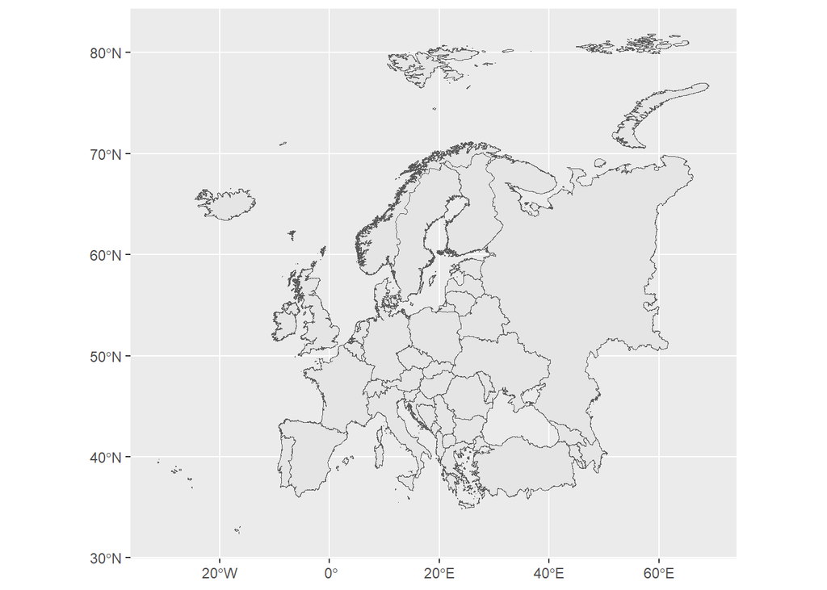

```r
ggplot()+
  geom_sf(data = Europe)
```

## 4. Add colors

I copy the hex colors from coolors

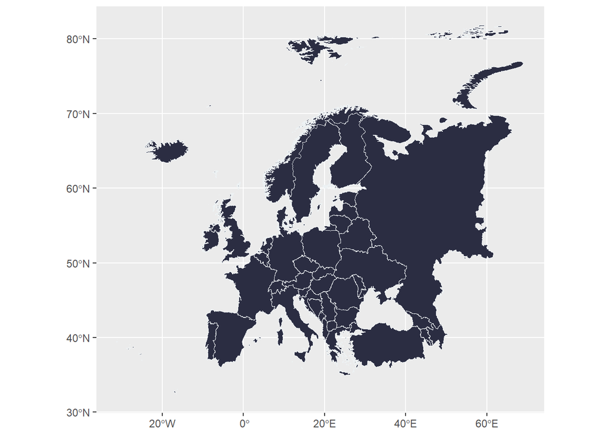

```r
ggplot()+
  geom_sf(data = Europe,
          colour = "#edf2f4",
          fill = "#2b2d42",
          size=0.5)
```

## 5. Change background color

You can eliminate the grids and the change the background color in ggplot

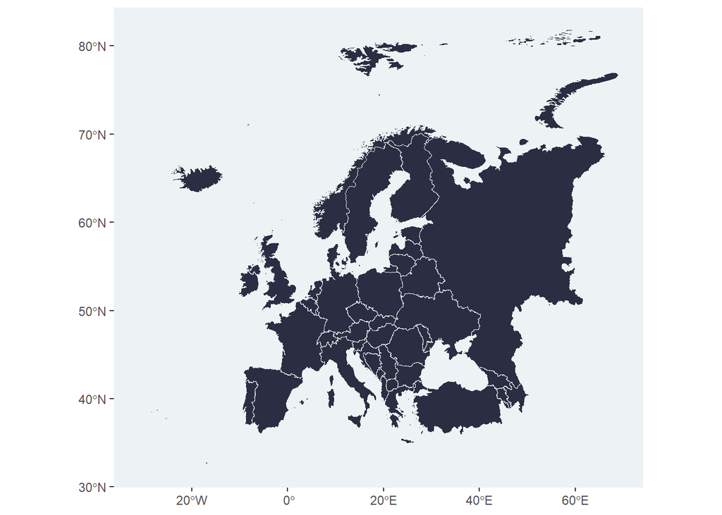

```r
ggplot()+
  geom_sf(data = Europe,
          colour = "#edf2f4",
          fill = "#2b2d42",
          size=0.5)+
  theme(
        panel.grid.major = element_blank(),
        panel.grid.minor = element_blank(),
        panel.background = element_rect(fill = '#edf2f4'),
        legend.background = element_rect(fill = '#edf2f4'))
```

## 6. Add limits

Reduce to focus in your area of interest

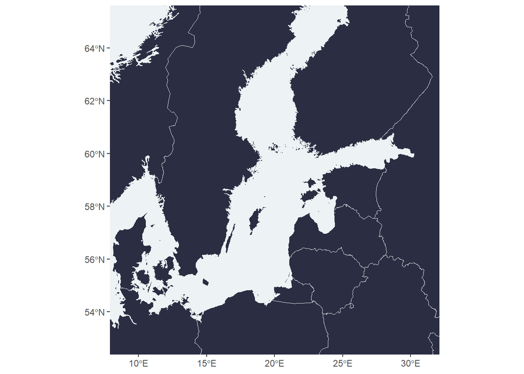

```r
ggplot()+
  geom_sf(data = Europe,
          colour = "#edf2f4",
          fill = "#2b2d42",
          size=0.5)+
  theme(
        panel.grid.major = element_blank(),
        panel.grid.minor = element_blank(),
        panel.background = element_rect(fill = '#edf2f4'),
        legend.background = element_rect(fill = '#edf2f4'))+

  coord_sf(xlim = c(9, 31),ylim = c(53, 65))
```

## 7. Add scale

Load the package **ggspatial** to add a scale and an north arrow

```r
library(ggspatial)
```

**br** is from bottom right  
**bar_cols** is for column colors  
**text_col** is for the color of the text

```
## Scale on map varies by more than 10%, scale bar may be inaccurate
```

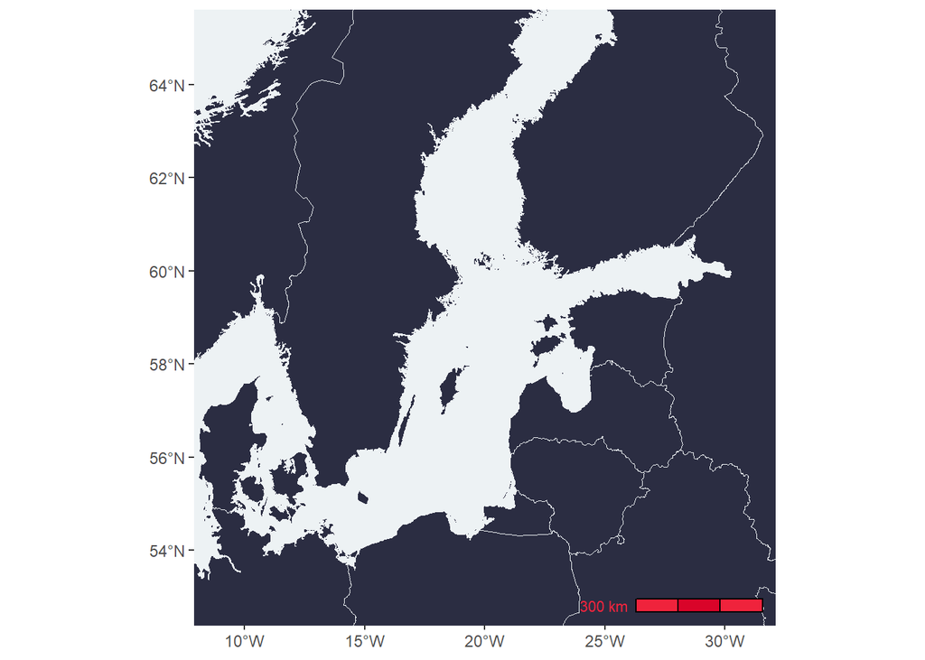

```r
ggplot()+
  geom_sf(data = Europe,
          colour = "#edf2f4",
          fill = "#2b2d42",
          size=0.5)+
  theme(
        panel.grid.major = element_blank(),
        panel.grid.minor = element_blank(),
        panel.background = element_rect(fill = '#edf2f4'),
        legend.background = element_rect(fill = '#edf2f4'))+

  coord_sf(xlim = c(9, 31),ylim = c(53, 65))+
    scale_x_continuous(labels = function(x) paste0(x, '\u00B0', "W")) +
    scale_y_continuous(labels = function(x) paste0(x, '\u00B0', "N")) +

  annotation_scale(location = "br",bar_cols = c("#ef233c", "#d90429"),text_col = '#ef233c')
```